# Exploratory Data Analysis: PowerCo Case Subscription

The Datasets

The dataset ml_case_training_output.csv named as pco_output contains:

```
    id: contact id *churn: has the client churned over the next 3 months
```

The dataset ml_case_training_hist_data.csv named as pco_hist contains the history of energy and power consumption per client:

```
    id: contact id price_date: reference dateprice_p1_var: price of energy for the 1st period price_p2_var: price of energy for the 2nd periodprice_p3_var: price of energy for the 3rd period price_p1_fix: price of power for the 1st periodprice_p2_fix: price of power for the 2nd period *price_p3_fix: price of power for the 3rd period
```

The dataset ml_case_training_data.csv contains:

```
    id: contact id
    activity_new: category of the company's activity. 419 unique values, remove NaN
    campaign_disc_elec: code of the electricity campaign the customer last subscribed to. 0 non-null
    channel_sales: code of the sales channel
    cons_12m: electricity consumption of the past 12 months
    cons_gas_12m: gas consumption of the past 12 months
    cons_last_month: electricity consupmtion of the last month
    date_activ: date of activation of the contract
    date_end: registered date of the end of the contract
    date_first_activ: date of first contract of the client
    date_modif_prod: date of last modification of the product
    date_renewal: date of the next contract renewal
    forecast_base_bill_ele: forecasted electricity bill baseline for next month
    forecast_base_bill_year: forecasted electricity bill baseline for calendar year
    forecast_bill_12m: forecasted electricity bill baseline for 12 months
    forecast_cons: forecasted electricity consumption for next month
    forecast_cons_12m: forecasted electricity consumption for next 12 months
    forecast_cons_year: forecasted electricity consumption for next calendar year
    forecast_discount_energy: forecasted value of current discount
    forecast_meter_rent_12m: forecasted bill of meter rental for the next 12 months
    forecast_price_energy_p1: forecasted energy price for 1st period
    forecast_price_energy_p2: forecasted energy price for 2nd period
    forecast_price_pow_p1: forecasted power price for 1st period
    has_gas: indicated if client is also a gas client
    imp_cons: current paid consumption
    margin_gross_pow_ele: gross margin on power subscription
    margin_net_pow_ele: net margin on power subscription
    nb_prod_act: number of active products and services
    net_margin: total net margin
    num_years_antig: antiquity of the client (in number of years)
    origin_up: code of the electricity campaign the customer first subscribed to
    pow_max: subscribed power
```

# Importing Libraries

```python
# Import libraries
import pandas as pd
import matplotlib.pyplot as plt
import seaborn as sns
import numpy as np
import missingno as msno
from scipy.stats import zscore as zscore
```

```python
# list of dates
date_list = ['date_activ','date_end','date_first_activ','date_modif_prod','date_renewal']

# Read in dataset
df_main = pd.read_csv("G:\\virtual experience\\BCG\\ml_case_training_data(1).csv", parse_dates=date_list)
df_hist = pd.read_csv("G:\\virtual experience\\BCG\\ml_case_training_hist_data(1).csv", parse_dates=['price_date'])
df_out = pd.read_csv("G:\\virtual experience\\BCG\\ml_case_training_output(1).csv")
```

```python
# customer attrition in the last 3 months
attrition_rate = df_out['churn'].value_counts() / df_out.shape[0] * 100
print('Attrition rate: \n', attrition_rate)
```

```
Attrition rate:
 0    90.090706
1     9.909294
Name: churn, dtype: float64
```

Observation: Around 90% people stayed while 10% left in the last three months

# Historical Pricing Data

```python
df_hist.head()
```

|  | id | price_date | price_p1_var | price_p2_var | price_p3_var | price_p1_fix | price_p2_fix | price_p3_fix |
| --- | --- | --- | --- | --- | --- | --- | --- | --- |
| 0 | 038af19179925da21a25619c5a24b745 | 2015-01-01 | 0.151367 | 0.0 | 0.0 | 44.266931 | 0.0 | 0.0 |
| 1 | 038af19179925da21a25619c5a24b745 | 2015-02-01 | 0.151367 | 0.0 | 0.0 | 44.266931 | 0.0 | 0.0 |
| 2 | 038af19179925da21a25619c5a24b745 | 2015-03-01 | 0.151367 | 0.0 | 0.0 | 44.266931 | 0.0 | 0.0 |
| 3 | 038af19179925da21a25619c5a24b745 | 2015-04-01 | 0.149626 | 0.0 | 0.0 | 44.266931 | 0.0 | 0.0 |
| 4 | 038af19179925da21a25619c5a24b745 | 2015-05-01 | 0.149626 | 0.0 | 0.0 | 44.266931 | 0.0 | 0.0 |

```python
df_hist.describe()
```

|  | price_p1_var | price_p2_var | price_p3_var | price_p1_fix | price_p2_fix | price_p3_fix |
| --- | --- | --- | --- | --- | --- | --- |
| count | 191643.000000 | 191643.000000 | 191643.000000 | 191643.000000 | 191643.000000 | 191643.000000 |
| mean | 0.140991 | 0.054412 | 0.030712 | 43.325546 | 10.698201 | 6.455436 |
| std | 0.025117 | 0.050033 | 0.036335 | 5.437952 | 12.856046 | 7.782279 |
| min | 0.000000 | 0.000000 | 0.000000 | -0.177779 | -0.097752 | -0.065172 |
| 25% | 0.125976 | 0.000000 | 0.000000 | 40.728885 | 0.000000 | 0.000000 |
| 50% | 0.146033 | 0.085483 | 0.000000 | 44.266930 | 0.000000 | 0.000000 |
| 75% | 0.151635 | 0.101780 | 0.072558 | 44.444710 | 24.339581 | 16.226389 |
| max | 0.280700 | 0.229788 | 0.114102 | 59.444710 | 36.490692 | 17.458221 |

```python
df_hist.isnull().sum()
```

```
id                 0
price_date         0
price_p1_var    1359
price_p2_var    1359
price_p3_var    1359
price_p1_fix    1359
price_p2_fix    1359
price_p3_fix    1359
dtype: int64
```

# Historical Customer Data

```python
df_main.head()
```

|  | id | activity_new | campaign_disc_ele | channel_sales | cons_12m | cons_gas_12m | cons_last_month | date_activ | date_end | date_first_activ | ... | forecast_price_pow_p1 | has_gas | imp_cons | margin_gross_pow_ele | margin_net_pow_ele | nb_prod_act | net_margin | num_years_antig | origin_up | pow_max |
| --- | --- | --- | --- | --- | --- | --- | --- | --- | --- | --- | --- | --- | --- | --- | --- | --- | --- | --- | --- | --- | --- |
| 0 | 48ada52261e7cf58715202705a0451c9 | esoiiifxdlbkcsluxmfuacbdckommixw | NaN | lmkebamcaaclubfxadlmueccxoimlema | 309275 | 0 | 10025 | 2012-11-07 | 2016-11-06 | NaT | ... | 58.995952 | f | 831.8 | -41.76 | -41.76 | 1 | 1732.36 | 3 | ldkssxwpmemidmecebumciepifcamkci | 180.000 |
| 1 | 24011ae4ebbe3035111d65fa7c15bc57 | NaN | NaN | foosdfpfkusacimwkcsosbicdxkicaua | 0 | 54946 | 0 | 2013-06-15 | 2016-06-15 | NaT | ... | 40.606701 | t | 0.0 | 25.44 | 25.44 | 2 | 678.99 | 3 | lxidpiddsbxsbosboudacockeimpuepw | 43.648 |
| 2 | d29c2c54acc38ff3c0614d0a653813dd | NaN | NaN | NaN | 4660 | 0 | 0 | 2009-08-21 | 2016-08-30 | NaT | ... | 44.311378 | f | 0.0 | 16.38 | 16.38 | 1 | 18.89 | 6 | kamkkxfxxuwbdslkwifmmcsiusiuosws | 13.800 |
| 3 | 764c75f661154dac3a6c254cd082ea7d | NaN | NaN | foosdfpfkusacimwkcsosbicdxkicaua | 544 | 0 | 0 | 2010-04-16 | 2016-04-16 | NaT | ... | 44.311378 | f | 0.0 | 28.60 | 28.60 | 1 | 6.60 | 6 | kamkkxfxxuwbdslkwifmmcsiusiuosws | 13.856 |
| 4 | bba03439a292a1e166f80264c16191cb | NaN | NaN | lmkebamcaaclubfxadlmueccxoimlema | 1584 | 0 | 0 | 2010-03-30 | 2016-03-30 | NaT | ... | 44.311378 | f | 0.0 | 30.22 | 30.22 | 1 | 25.46 | 6 | kamkkxfxxuwbdslkwifmmcsiusiuosws | 13.200 |

5 rows × 32 columns

```python
df_main.describe()
```

|  | campaign_disc_ele | cons_12m | cons_gas_12m | cons_last_month | forecast_base_bill_ele | forecast_base_bill_year | forecast_bill_12m | forecast_cons | forecast_cons_12m | forecast_cons_year | ... | forecast_price_energy_p1 | forecast_price_energy_p2 | forecast_price_pow_p1 | imp_cons | margin_gross_pow_ele | margin_net_pow_ele | nb_prod_act | net_margin | num_years_antig | pow_max |
| --- | --- | --- | --- | --- | --- | --- | --- | --- | --- | --- | --- | --- | --- | --- | --- | --- | --- | --- | --- | --- | --- |
| count | 0.0 | 1.609600e+04 | 1.609600e+04 | 1.609600e+04 | 3508.000000 | 3508.000000 | 3508.000000 | 3508.000000 | 16096.000000 | 16096.000000 | ... | 15970.000000 | 15970.000000 | 15970.000000 | 16096.000000 | 16083.000000 | 16083.000000 | 16096.000000 | 16081.000000 | 16096.000000 | 16093.000000 |
| mean | NaN | 1.948044e+05 | 3.191164e+04 | 1.946154e+04 | 335.843857 | 335.843857 | 3837.441866 | 206.845165 | 2370.555949 | 1907.347229 | ... | 0.135901 | 0.052951 | 43.533496 | 196.123447 | 22.462276 | 21.460318 | 1.347788 | 217.987028 | 5.030629 | 20.604131 |
| std | NaN | 6.795151e+05 | 1.775885e+05 | 8.235676e+04 | 649.406000 | 649.406000 | 5425.744327 | 455.634288 | 4035.085664 | 5257.364759 | ... | 0.026252 | 0.048617 | 5.212252 | 494.366979 | 23.700883 | 27.917349 | 1.459808 | 366.742030 | 1.676101 | 21.772421 |
| min | NaN | -1.252760e+05 | -3.037000e+03 | -9.138600e+04 | -364.940000 | -364.940000 | -2503.480000 | 0.000000 | -16689.260000 | -85627.000000 | ... | 0.000000 | 0.000000 | -0.122184 | -9038.210000 | -525.540000 | -615.660000 | 1.000000 | -4148.990000 | 1.000000 | 1.000000 |
| 25% | NaN | 5.906250e+03 | 0.000000e+00 | 0.000000e+00 | 0.000000 | 0.000000 | 1158.175000 | 0.000000 | 513.230000 | 0.000000 | ... | 0.115237 | 0.000000 | 40.606701 | 0.000000 | 11.960000 | 11.950000 | 1.000000 | 51.970000 | 4.000000 | 12.500000 |
| 50% | NaN | 1.533250e+04 | 0.000000e+00 | 9.010000e+02 | 162.955000 | 162.955000 | 2187.230000 | 42.215000 | 1179.160000 | 378.000000 | ... | 0.142881 | 0.086163 | 44.311378 | 44.465000 | 21.090000 | 20.970000 | 1.000000 | 119.680000 | 5.000000 | 13.856000 |
| 75% | NaN | 5.022150e+04 | 0.000000e+00 | 4.127000e+03 | 396.185000 | 396.185000 | 4246.555000 | 228.117500 | 2692.077500 | 1994.250000 | ... | 0.146348 | 0.098837 | 44.311378 | 218.090000 | 29.640000 | 29.640000 | 1.000000 | 275.810000 | 6.000000 | 19.800000 |
| max | NaN | 1.609711e+07 | 4.188440e+06 | 4.538720e+06 | 12566.080000 | 12566.080000 | 81122.630000 | 9682.890000 | 103801.930000 | 175375.000000 | ... | 0.273963 | 0.195975 | 59.444710 | 15042.790000 | 374.640000 | 374.640000 | 32.000000 | 24570.650000 | 16.000000 | 500.000000 |

8 rows × 22 columns

Obseravtion: 1) Average tenure of customer is 5 years. Some leave after 1 year, while some stay for as long as 16. 2) Average net margin is $217.

```python
df_main.isnull().sum()
```

```
id                              0
activity_new                 9545
campaign_disc_ele           16096
channel_sales                4218
cons_12m                        0
cons_gas_12m                    0
cons_last_month                 0
date_activ                      0
date_end                        2
date_first_activ            12588
date_modif_prod               157
date_renewal                   40
forecast_base_bill_ele      12588
forecast_base_bill_year     12588
forecast_bill_12m           12588
forecast_cons               12588
forecast_cons_12m               0
forecast_cons_year              0
forecast_discount_energy      126
forecast_meter_rent_12m         0
forecast_price_energy_p1      126
forecast_price_energy_p2      126
forecast_price_pow_p1         126
has_gas                         0
imp_cons                        0
margin_gross_pow_ele           13
margin_net_pow_ele             13
nb_prod_act                     0
net_margin                     15
num_years_antig                 0
origin_up                      87
pow_max                         3
dtype: int64
```

```python
# Identify the percentage of nullity in the dataframe for each collumn
missing_values_main_perc = df_main.isnull().mean() * 100
print('Percentage of Missing Values:\n', missing_values_main_perc)
```

```
Percentage of Missing Values:
 id                            0.000000
activity_new                 59.300447
campaign_disc_ele           100.000000
channel_sales                26.205268
cons_12m                      0.000000
cons_gas_12m                  0.000000
cons_last_month               0.000000
date_activ                    0.000000
date_end                      0.012425
date_first_activ             78.205765
date_modif_prod               0.975398
date_renewal                  0.248509
forecast_base_bill_ele       78.205765
forecast_base_bill_year      78.205765
forecast_bill_12m            78.205765
forecast_cons                78.205765
forecast_cons_12m             0.000000
forecast_cons_year            0.000000
forecast_discount_energy      0.782803
forecast_meter_rent_12m       0.000000
forecast_price_energy_p1      0.782803
forecast_price_energy_p2      0.782803
forecast_price_pow_p1         0.782803
has_gas                       0.000000
imp_cons                      0.000000
margin_gross_pow_ele          0.080765
margin_net_pow_ele            0.080765
nb_prod_act                   0.000000
net_margin                    0.093191
num_years_antig               0.000000
origin_up                     0.540507
pow_max                       0.018638
dtype: float64
```

Obseravtions: 1) The forecast_base_bill_ele, forecast_base_bill_year, forecast_bill_12m, and forecast_cons columns are each missing 78.2% of its data 2) The activity_new column is missing 59.3% of its data 3) The campaign_disc_ele column is missing completely 4) The channel_sales column is missing 26.2% of its data 5) The date_end column is missing 0.01% of its data 6) The date_first*activ* column is missing 78.2% of its data 7) The date_modif_prod column is missing 0.9% of its data 8) The date_renewal column is missing 0.24% of it data 9) The marging_gross_pow_ele and margin_net_pow_ele columns are both missing 0.08% of its data 10) The net_margin column is missing 0.09% of its data 11) The origin_up column is missing 0.54% of its data 12) The pow_max column is missing 0.018% of its data

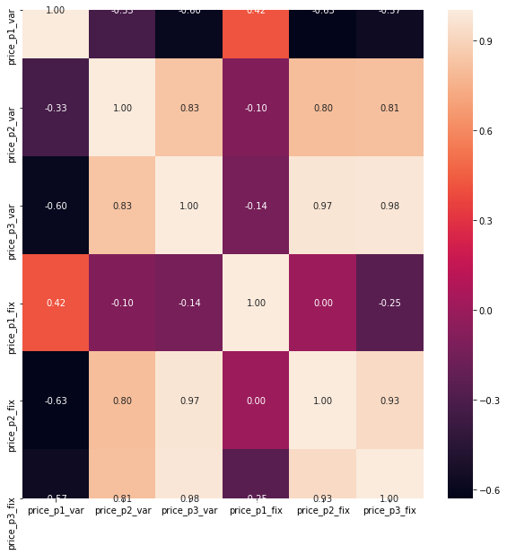

```python
plt.figure(figsize=(10,10))
sns.heatmap(df_hist.corr(),annot=True,fmt='.2f')
plt.show()
```

```python
# Identify the index of the IDs containing missing values.
hist_NAN_index = df_hist[df_hist.isnull().any(axis=1)].index.values.tolist()

#Print prior to imputing missing values
print(df_hist.iloc[hist_NAN_index,3:9].head())

# Fill NaNs using forward fill
df_hist.fillna(method = 'ffill', inplace=True)

print(df_hist.iloc[hist_NAN_index,3:9].head())
```

```
     price_p2_var  price_p3_var  price_p1_fix  price_p2_fix  price_p3_fix
75            NaN           NaN           NaN           NaN           NaN
221           NaN           NaN           NaN           NaN           NaN
377           NaN           NaN           NaN           NaN           NaN
413           NaN           NaN           NaN           NaN           NaN
461           NaN           NaN           NaN           NaN           NaN
     price_p2_var  price_p3_var  price_p1_fix  price_p2_fix  price_p3_fix
75       0.000000      0.000000     44.266931      0.000000      0.000000
221      0.000000      0.000000     44.266931      0.000000      0.000000
377      0.087970      0.000000     44.266931      0.000000      0.000000
413      0.102239      0.070381     40.565969     24.339581     16.226389
461      0.000000      0.000000     44.266931      0.000000      0.000000
```

```python
# Merge output dataset with historical forward fill dataset
df_hist_merged = df_hist.merge(right=df_out,on=['id'])
df_hist_merged.head()
```

|  | id | price_date | price_p1_var | price_p2_var | price_p3_var | price_p1_fix | price_p2_fix | price_p3_fix | churn |
| --- | --- | --- | --- | --- | --- | --- | --- | --- | --- |
| 0 | 038af19179925da21a25619c5a24b745 | 2015-01-01 | 0.151367 | 0.0 | 0.0 | 44.266931 | 0.0 | 0.0 | 0 |
| 1 | 038af19179925da21a25619c5a24b745 | 2015-02-01 | 0.151367 | 0.0 | 0.0 | 44.266931 | 0.0 | 0.0 | 0 |
| 2 | 038af19179925da21a25619c5a24b745 | 2015-03-01 | 0.151367 | 0.0 | 0.0 | 44.266931 | 0.0 | 0.0 | 0 |
| 3 | 038af19179925da21a25619c5a24b745 | 2015-04-01 | 0.149626 | 0.0 | 0.0 | 44.266931 | 0.0 | 0.0 | 0 |
| 4 | 038af19179925da21a25619c5a24b745 | 2015-05-01 | 0.149626 | 0.0 | 0.0 | 44.266931 | 0.0 | 0.0 | 0 |

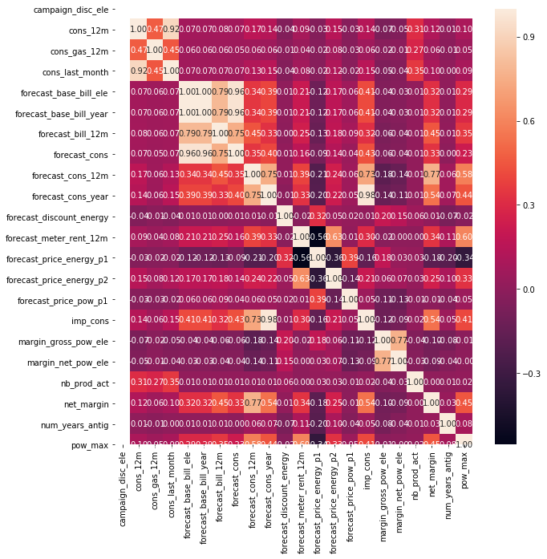

```python
plt.figure(figsize=(10,10))
sns.heatmap(df_main.corr(),annot=True,fmt='.2f')
plt.show()
```

```python
# Function to identify numeric features
def numeric_features(dataset):
    numeric_col = dataset.select_dtypes(include=np.number).columns.tolist()
    return dataset[numeric_col].head()

numeric_columns = numeric_features(df_main)
print("Numerical Features")
print(numeric_columns)

print("===="*20)



# Function to identify categorical features
def categorical_features(dataset):
    categorical_col = dataset.select_dtypes(exclude=np.number).columns.tolist()
    return dataset[categorical_col].head()

categorical_columns = categorical_features(df_main)
print("Categorical Features:")
print(categorical_columns)
```

```
Numerical Features
   campaign_disc_ele  cons_12m  cons_gas_12m  cons_last_month  \
0                NaN    309275             0            10025
1                NaN         0         54946                0
2                NaN      4660             0                0
3                NaN       544             0                0
4                NaN      1584             0                0

   forecast_base_bill_ele  forecast_base_bill_year  forecast_bill_12m  \
0                     NaN                      NaN                NaN
1                     NaN                      NaN                NaN
2                     NaN                      NaN                NaN
3                     NaN                      NaN                NaN
4                     NaN                      NaN                NaN

   forecast_cons  forecast_cons_12m  forecast_cons_year  ...  \
0            NaN           26520.30               10025  ...
1            NaN               0.00                   0  ...
2            NaN             189.95                   0  ...
3            NaN              47.96                   0  ...
4            NaN             240.04                   0  ...

   forecast_price_energy_p1  forecast_price_energy_p2  forecast_price_pow_p1  \
0                  0.095919                  0.088347              58.995952
1                  0.114481                  0.098142              40.606701
2                  0.145711                  0.000000              44.311378
3                  0.165794                  0.087899              44.311378
4                  0.146694                  0.000000              44.311378

   imp_cons  margin_gross_pow_ele  margin_net_pow_ele  nb_prod_act  \
0     831.8                -41.76              -41.76            1
1       0.0                 25.44               25.44            2
2       0.0                 16.38               16.38            1
3       0.0                 28.60               28.60            1
4       0.0                 30.22               30.22            1

   net_margin  num_years_antig  pow_max
0     1732.36                3  180.000
1      678.99                3   43.648
2       18.89                6   13.800
```

[output cut: 11 more lines]

```
4  bba03439a292a1e166f80264c16191cb                               NaN

                      channel_sales date_activ   date_end date_first_activ  \
0  lmkebamcaaclubfxadlmueccxoimlema 2012-11-07 2016-11-06              NaT
1  foosdfpfkusacimwkcsosbicdxkicaua 2013-06-15 2016-06-15              NaT
2                               NaN 2009-08-21 2016-08-30              NaT
3  foosdfpfkusacimwkcsosbicdxkicaua 2010-04-16 2016-04-16              NaT
4  lmkebamcaaclubfxadlmueccxoimlema 2010-03-30 2016-03-30              NaT

  date_modif_prod date_renewal has_gas                         origin_up
0      2012-11-07   2015-11-09       f  ldkssxwpmemidmecebumciepifcamkci
1             NaT   2015-06-23       t  lxidpiddsbxsbosboudacockeimpuepw
2      2009-08-21   2015-08-31       f  kamkkxfxxuwbdslkwifmmcsiusiuosws
3      2010-04-16   2015-04-17       f  kamkkxfxxuwbdslkwifmmcsiusiuosws
4      2010-03-30   2015-03-31       f  kamkkxfxxuwbdslkwifmmcsiusiuosws
```

```python
# Merge output dataset with historical forward fill dataset
df_main_merged = df_main.merge(right=df_out,on=['id'])
df_main_merged.head()
```

|  | id | activity_new | campaign_disc_ele | channel_sales | cons_12m | cons_gas_12m | cons_last_month | date_activ | date_end | date_first_activ | ... | has_gas | imp_cons | margin_gross_pow_ele | margin_net_pow_ele | nb_prod_act | net_margin | num_years_antig | origin_up | pow_max | churn |
| --- | --- | --- | --- | --- | --- | --- | --- | --- | --- | --- | --- | --- | --- | --- | --- | --- | --- | --- | --- | --- | --- |
| 0 | 48ada52261e7cf58715202705a0451c9 | esoiiifxdlbkcsluxmfuacbdckommixw | NaN | lmkebamcaaclubfxadlmueccxoimlema | 309275 | 0 | 10025 | 2012-11-07 | 2016-11-06 00:00:00 | NaN | ... | f | 831.8 | -41.76 | -41.76 | 1 | 1732.36 | 3 | ldkssxwpmemidmecebumciepifcamkci | 180.000 | 0 |
| 1 | 24011ae4ebbe3035111d65fa7c15bc57 | NaN | NaN | foosdfpfkusacimwkcsosbicdxkicaua | 0 | 54946 | 0 | 2013-06-15 | 2016-06-15 00:00:00 | NaN | ... | t | 0.0 | 25.44 | 25.44 | 2 | 678.99 | 3 | lxidpiddsbxsbosboudacockeimpuepw | 43.648 | 1 |
| 2 | d29c2c54acc38ff3c0614d0a653813dd | NaN | NaN | NaN | 4660 | 0 | 0 | 2009-08-21 | 2016-08-30 00:00:00 | NaN | ... | f | 0.0 | 16.38 | 16.38 | 1 | 18.89 | 6 | kamkkxfxxuwbdslkwifmmcsiusiuosws | 13.800 | 0 |
| 3 | 764c75f661154dac3a6c254cd082ea7d | NaN | NaN | foosdfpfkusacimwkcsosbicdxkicaua | 544 | 0 | 0 | 2010-04-16 | 2016-04-16 00:00:00 | NaN | ... | f | 0.0 | 28.60 | 28.60 | 1 | 6.60 | 6 | kamkkxfxxuwbdslkwifmmcsiusiuosws | 13.856 | 0 |
| 4 | bba03439a292a1e166f80264c16191cb | NaN | NaN | lmkebamcaaclubfxadlmueccxoimlema | 1584 | 0 | 0 | 2010-03-30 | 2016-03-30 00:00:00 | NaN | ... | f | 0.0 | 30.22 | 30.22 | 1 | 25.46 | 6 | kamkkxfxxuwbdslkwifmmcsiusiuosws | 13.200 | 0 |

5 rows × 33 columns

```python
# Function to impute missing values with mean or median
def fill_null_values(dataset, value):
    nulls = pd.DataFrame(dataset.isnull().sum().sort_values(ascending=False))
    nulls = nulls[nulls>0]
    nulls.columns = ['Null Count']
    nulls.index.name = 'Feature'


    for column in nulls[nulls["Null Count"]> 0].index:
        if dataset[column].dtype == np.number and value == 0:
            dataset[column].fillna(dataset[column].mean(), inplace = True)
        elif value == 1:
            dataset[column].fillna(dataset[column].median(), inplace = True)
        else:
            dataset[column].fillna("NaN", inplace = True)
    print(dataset.isnull().sum())
    return dataset

dataframe=fill_null_values(df_main_merged,0)
```

```
id                              0
activity_new                    0
campaign_disc_ele           16096
channel_sales                   0
cons_12m                        0
cons_gas_12m                    0
cons_last_month                 0
date_activ                      0
date_end                        0
date_first_activ                0
date_modif_prod                 0
date_renewal                    0
forecast_base_bill_ele          0
forecast_base_bill_year         0
forecast_bill_12m               0
forecast_cons                   0
forecast_cons_12m               0
forecast_cons_year              0
forecast_discount_energy        0
forecast_meter_rent_12m         0
forecast_price_energy_p1        0
forecast_price_energy_p2        0
forecast_price_pow_p1           0
has_gas                         0
imp_cons                        0
margin_gross_pow_ele            0
margin_net_pow_ele              0
nb_prod_act                     0
net_margin                      0
num_years_antig                 0
origin_up                       0
pow_max                         0
churn                           0
dtype: int64
```

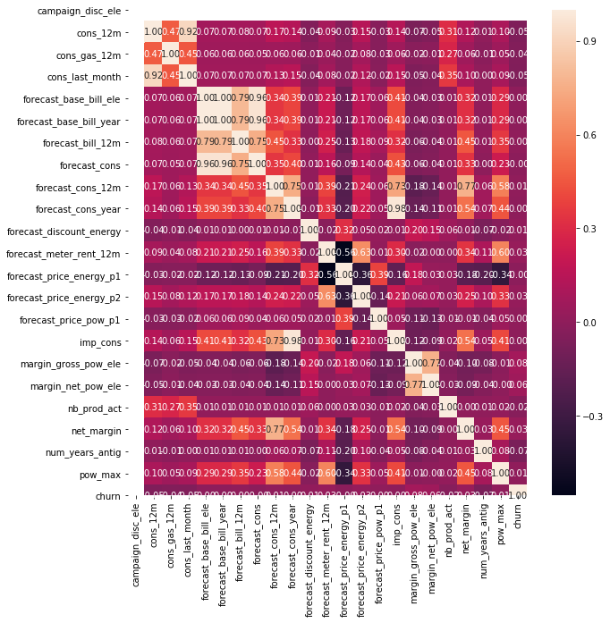

```python
plt.figure(figsize=(10,10))
sns.heatmap(df_main_merged.corr(),annot=True,fmt='.2f')
plt.show()
```

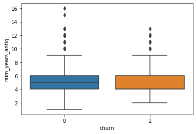

```python
target=df_main_merged["churn"]

ax = sns.boxplot(y="num_years_antig", x=target, data=df_main_merged)
```

Obseravtions: 1) Average age of customer attrition is 5 years. 2) Average age of customer churn is about 4 years.

```python
# Highest netting electricity subscription campaign

df_main_merged.groupby('origin_up')['net_margin'].agg('sum').sort_values(ascending=False)
```

```
origin_up
lxidpiddsbxsbosboudacockeimpuepw    1.827298e+06
ldkssxwpmemidmecebumciepifcamkci    9.078753e+05
kamkkxfxxuwbdslkwifmmcsiusiuosws    7.483358e+05
NaN                                 2.491341e+04
usapbepcfoloekilkwsdiboslwaxobdp    2.504000e+02
ewxeelcelemmiwuafmddpobolfuxioce    4.622000e+01
Name: net_margin, dtype: float64
```

```python
# Select current customers with positive net margins
top_customers = df_main_merged.loc[(df_main_merged['churn']>=0) & (df_main_merged['net_margin']>0),['id','num_years_antig','net_margin']]

# Top 10 customers by net margin
top_customers.sort_values(by=['net_margin'],ascending=False).head(10)
```

|  | id | num_years_antig | net_margin |
| --- | --- | --- | --- |
| 2872 | fb7dcb0f4e0dc4ee54874eab2607c4da | 3 | 24570.65 |
| 11828 | d00e8a9951b5551d8f02e45f9ed2b0dd | 3 | 10203.50 |
| 7131 | 78bd1c5c0c67f2be6de89b19df5f8861 | 3 | 5625.14 |
| 13622 | 818b8bca0a9d7668252d46b978169325 | 4 | 4346.37 |
| 8612 | a3a739686fbd5ba8b4a21ec835507b6d | 4 | 4305.79 |
| 333 | 89b3406c3ba717f1b788ceeb5af9e8b9 | 3 | 4161.74 |
| 12368 | 4519e6a8928a015819466fc9de0fa49e | 3 | 4040.60 |
| 4256 | e8948a5469344e9ad0dfcacbb705f709 | 4 | 3768.16 |
| 6595 | 933527d7a2f669af49075a2380c10ded | 4 | 3744.72 |
| 7048 | 43580ef6cc40fcfd0a9b76eee17a267a | 4 | 3716.78 |

Observation: These are the top best performers in customers. Since most are in the average age of churn, special emphasis should be given to retain them.

# Churn rate per sales channel

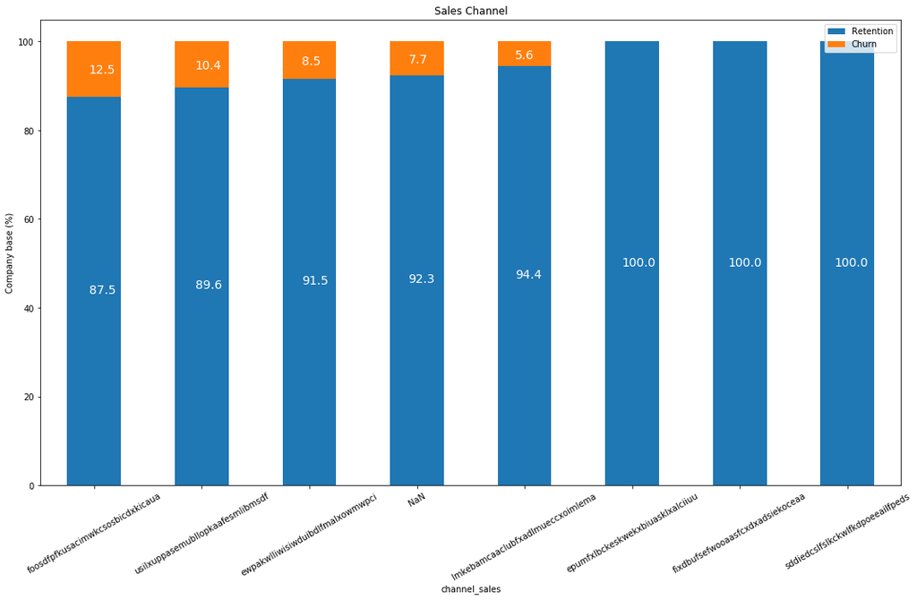

```python
def plot_stacked_bars(dataframe, title_, size_=(18, 10), rot_=0, legend_="upper right"):
    ax=dataframe.plot(kind="bar",stacked=True,figsize=size_,rot=rot_,title=title_)
    annotate_stacked_bars(ax, textsize=14)
    plt.legend(["Retention", "Churn"], loc=legend_)
    plt.ylabel("Company base (%)")
    plt.show()

def annotate_stacked_bars(ax, pad=0.99, colour="white", textsize=13):
    for p in ax.patches:
        value=str(round(p.get_height(),1))
        if value=='0.0':
            continue
        ax.annotate(value,
                    ((p.get_x()+p.get_width()/2)*pad-0.05, (p.get_y()+p.get_height()/2)*pad),
                    color=colour,
                    size=textsize,
                   )

channel=df_main_merged[["id","channel_sales", "churn"]]
channel=channel.groupby([channel["channel_sales"],channel["churn"]])["id"].count().unstack(level=1).fillna(0)
channel_churn= (channel.div(channel.sum(axis=1), axis=0)*100).sort_values(by=[1], ascending=False)
plot_stacked_bars(channel_churn, "Sales Channel", rot_=30)
```